# SCC summary stats

Andrey Ziyatdinov

2018-02-09

# Convert to LDSC summary stats format

**Sample size:** We take the sample size (`N`) from the Sup. Material (`Supplemental file template_Yuan_01152018.docx`) shared together with the summary statistics file (`Consortium_SCC_Meta_SNPonly_impu_filter_anno.txt`). The Sup. Table “Summary data for individual datasets by study” shows the total number of cases, 19,408, and controls 673,137, aggregated from 6 studies (Rotterdam, 23&Me, Harvard, Kaiser, deCODE and Ohio). That results in `N` = 692,545.

**Sub-sample of SNPs for LDSC:** We use only “reliable” SNPs from HapMap3 and allow LDSC to perform QC. We see from the output given below:

- The number of SNPs was reduced from 24,707,509 1,217,311 (1,216,298 with nonmissing beta).
- `Effect: [linear/logistic] regression coefficient (0 --> no effect; above 0 --> A1 is trait/risk increasing)`
  - `Median value of Effect was 0.0001, which seems sensible.`
- `Mean chi^2 = 1.161`
- `Lambda GC = 1.103` (it was `0.83` in the original analysis using 24,707,509 SNPs; Sup. Material)
- `Max chi^2 = 1009.816`
- `562 Genome-wide significant SNPs (some may have been removed by filtering).`

```
~/apps/ldsc/munge_sumstats.py \
  --sumstats ~/Data/SCC/GWAS/Consortium_SCC_Meta_SNPonly_impu_filter_anno.txt \
  --out scc \
  --merge-alleles ~/Data/ldsc/ref/w_hm3.snplist \
  --N 692545
```

```
* LD Score Regression (LDSC)
* Version 1.0.0
* (C) 2014-2015 Brendan Bulik-Sullivan and Hilary Finucane
* Broad Institute of MIT and Harvard / MIT Department of Mathematics
* GNU General Public License v3
Call:
./munge_sumstats.py \
--out scc \
--merge-alleles /Users/andreyziyatdinov/Data/ldsc/ref/w_hm3.snplist \
--N 692545.0 \
--sumstats /Users/andreyziyatdinov/Data/SCC/GWAS/Consortium_SCC_Meta_SNPonly_impu_filter_anno.txt

Interpreting column names as follows:
Allele2:    Allele 2, interpreted as non-ref allele for signed sumstat.
MarkerName: Variant ID (e.g., rs number)
Allele1:    Allele 1, interpreted as ref allele for signed sumstat.
Effect: [linear/logistic] regression coefficient (0 --> no effect; above 0 --> A1 is trait/risk increasing)
P.value:    p-Value

Reading list of SNPs for allele merge from /Users/andreyziyatdinov/Data/ldsc/ref/w_hm3.snplist
Read 1217311 SNPs for allele merge.
Reading sumstats from /Users/andreyziyatdinov/Data/SCC/GWAS/Consortium_SCC_Meta_SNPonly_impu_filter_anno.txt into memory 5000000 SNPs at a time.
Read 24707509 SNPs from --sumstats file.
Removed 23490500 SNPs not in --merge-alleles.
Removed 0 SNPs with missing values.
Removed 0 SNPs with INFO <= 0.9.
Removed 0 SNPs with MAF <= 0.01.
Removed 0 SNPs with out-of-bounds p-values.
Removed 540 variants that were not SNPs or were strand-ambiguous.
1216469 SNPs remain.
Removed 0 SNPs with duplicated rs numbers (1216469 SNPs remain).
Using N = 692545.0
Median value of Effect was 0.0001, which seems sensible.
Removed 171 SNPs whose alleles did not match --merge-alleles (1216298 SNPs remain).
Writing summary statistics for 1217311 SNPs (1216298 with nonmissing beta) to scc.sumstats.gz.

Metadata:
Mean chi^2 = 1.161
Lambda GC = 1.103
Max chi^2 = 1009.816
562 Genome-wide significant SNPs (some may have been removed by filtering).

Conversion finished at Thu Feb  8 15:00:21 2018
Total time elapsed: 1.0m:36.37s
```

# Estimation of h2

## Observed scale

```
~/apps/ldsc/ldsc.py \
  --h2 scc.sumstats.gz \
  --ref-ld-chr ~/Data/ldsc/ref/eur_w_ld_chr/ \
  --w-ld-chr ~/Data/ldsc/ref/eur_w_ld_chr/ \
  --out scc_h2
```

```
Total Observed scale h2: 0.0092 (0.0015)
Lambda GC: 1.105
Mean Chi^2: 1.1624
Intercept: 1.0388 (0.0084)
Ratio: 0.2389 (0.0517)
Analysis finished at Thu Feb  8 15:00:47 2018
Total time elapsed: 13.26s
```

## Liability scale

https://www.ncbi.nlm.nih.gov/pmc/articles/PMC5424654/:

> The incidence of metastatic BCC and SCC ranges between 0.00281–0.05% and 0.5–16%, respectively

```
~/apps/ldsc/ldsc.py \
  --h2 scc.sumstats.gz \
  --ref-ld-chr ~/Data/ldsc/ref/eur_w_ld_chr/ \
  --w-ld-chr ~/Data/ldsc/ref/eur_w_ld_chr/ \
  --out scc_h2_liab \
  --samp-prev 0.0288 \
  --pop-prev 0.001
```

```
Total Liability scale h2: 0.029 (0.0048)
Lambda GC: 1.105
Mean Chi^2: 1.1624
Intercept: 1.0388 (0.0084)
Ratio: 0.2389 (0.0517)
Analysis finished at Thu Feb  8 15:00:58 2018
Total time elapsed: 9.55s
```

# Run baseline LDSC model

- `Total Observed scale h2: 0.0088 (0.0021)`
- `Ratio: 0.2484 (0.1011)`: it is expected to be `0`, but values of 10-20% are common ([link](https://github.com/bulik/ldsc/wiki/Heritability-and-Genetic-Correlation)):

> Ratio is (intercept-1)/(mean(chi^2)-1), which measures the proportion of the inflation in the mean chi^2 that the LD Score regression intercept ascribes to causes other than polygenic heritability. The value of ratio should be close to zero, though in practice values of 10-20% are not uncommon, probably due to sample/reference LD Score mismatch or model misspecification (e.g., low LD variants have slightly higher h^2 per SNP)
- `Removed 1 SNPs with chi^2 > 692.545 (1085222 SNPs remain)`.

```
* LD Score Regression (LDSC)
* Version 1.0.0
* (C) 2014-2015 Brendan Bulik-Sullivan and Hilary Finucane
* Broad Institute of MIT and Harvard / MIT Department of Mathematics
* GNU General Public License v3
Call:
./ldsc.py \
--h2 scc.sumstats.gz \
--ref-ld-chr /Users/andreyziyatdinov/Data/ldsc/partition/baseline/baseline. \
--out scc_baseline \
--overlap-annot  \
--frqfile-chr /Users/andreyziyatdinov/Data/ldsc/ref/1000G_frq/1000G.mac5eur. \
--w-ld-chr /Users/andreyziyatdinov/Data/ldsc/ref/weights_hm3_no_hla/weights.

Beginning analysis at Thu Feb  8 15:00:58 2018
Reading summary statistics from scc.sumstats.gz ...
Read summary statistics for 1216298 SNPs.
Reading reference panel LD Score from /Users/andreyziyatdinov/Data/ldsc/partition/baseline/baseline.[1-22] ...
Read reference panel LD Scores for 1189907 SNPs.
Removing partitioned LD Scores with zero variance.
Reading regression weight LD Score from /Users/andreyziyatdinov/Data/ldsc/ref/weights_hm3_no_hla/weights.[1-22] ...
Read regression weight LD Scores for 1242190 SNPs.
After merging with reference panel LD, 1087970 SNPs remain.
After merging with regression SNP LD, 1085223 SNPs remain.
Removed 1 SNPs with chi^2 > 692.545 (1085222 SNPs remain)
Total Observed scale h2: 0.0088 (0.0021)
Categories: base_0 Coding_UCSC_0 Coding_UCSC.extend.500_0 Conserved_LindbladToh_0 Conserved_LindbladToh.extend.500_0 CTCF_Hoffman_0 CTCF_Hoffman.extend.500_0 DGF_ENCODE_0 DGF_ENCODE.extend.500_0 DHS_peaks_Trynka_0 DHS_Trynka_0 DHS_Trynka.extend.500_0 Enhancer_Andersson_0 Enhancer_Andersson.extend.50…
Lambda GC: 1.105
Mean Chi^2: 1.1621
Intercept: 1.0403 (0.0164)
Ratio: 0.2484 (0.1011)
Reading annot matrix from /Users/andreyziyatdinov/Data/ldsc/partition/baseline/baseline.[1-22] ...
Results printed to scc_baseline.results
Analysis finished at Thu Feb  8 15:02:52 2018
Total time elapsed: 1.0m:54.05s
```

## Distribution of prop. h2

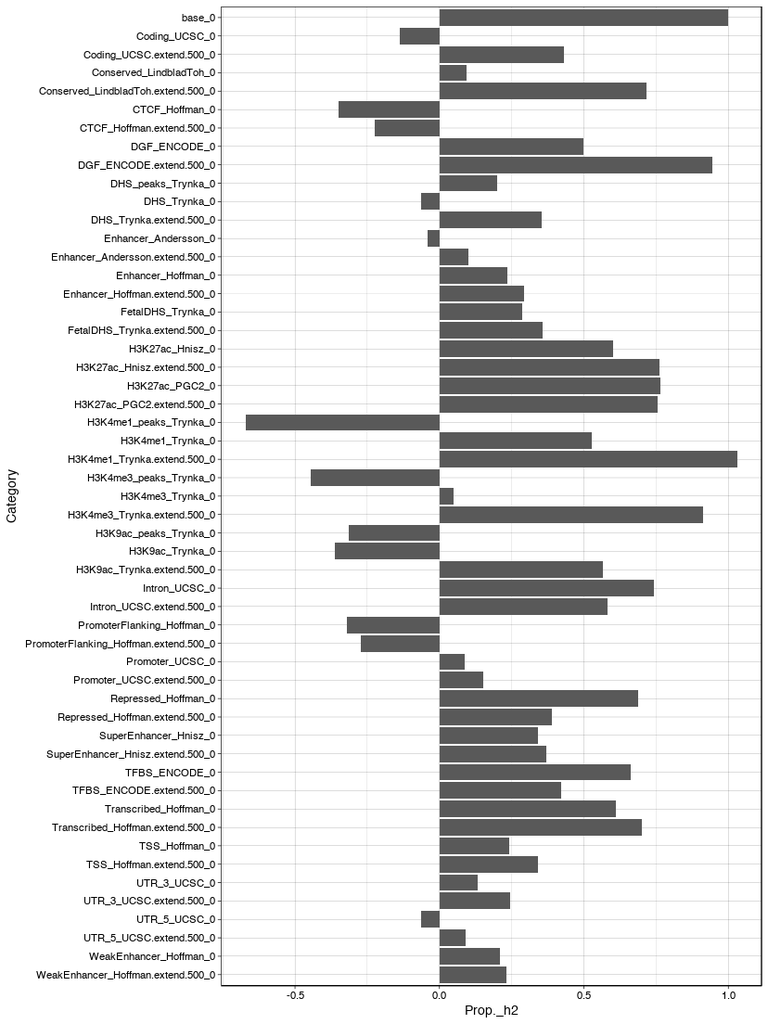

## Filtered results: FDR < 0.05

| Category | Prop._SNPs | Prop._h2 | Prop._h2_std_error | Enrichment | Enrichment_std_error | Enrichment_p | Enrichment_p_adj_fdr |
| --- | --- | --- | --- | --- | --- | --- | --- |
| Coding_UCSC.extend.500_0 | 0.0646 | 0.430 | 0.1241 | 6.66 | 1.922 | 0.000646 | 0.0336 |
| SuperEnhancer_Hnisz.extend.500_0 | 0.1716 | 0.369 | 0.0594 | 2.15 | 0.346 | 0.001756 | 0.0457 |

# Cell-type groups

| Category | Prop._SNPs | Prop._h2 | Prop._h2_std_error | Enrichment | Enrichment_std_error | Enrichment_p | Coefficient | Coefficient_std_error | Coefficient_z-score | Coefficient_p | Coefficient_p_adj_fdr |
| --- | --- | --- | --- | --- | --- | --- | --- | --- | --- | --- | --- |
| Immune | 0.2334 | 0.81595 | 0.330 | 3.4966 | 1.414 | 0.0240 | 5.83e-09 | 2.12e-09 | 2.755 | 0.00587 | 0.0587 |
| SkeletalMuscle | 0.1038 | -0.20395 | 0.143 | -1.9645 | 1.376 | 0.0716 | -7.68e-09 | 3.37e-09 | -2.275 | 0.02289 | 0.1145 |
| Adrenal_Pancreas | 0.0936 | -0.06864 | 0.127 | -0.7336 | 1.358 | 0.2225 | -4.27e-09 | 3.49e-09 | -1.222 | 0.22187 | 0.3170 |
| Liver | 0.0722 | -0.08810 | 0.136 | -1.2205 | 1.889 | 0.2736 | -5.99e-09 | 3.92e-09 | -1.528 | 0.12650 | 0.3023 |
| Cardiovascular | 0.1111 | -0.09905 | 0.208 | -0.8914 | 1.872 | 0.3250 | -4.18e-09 | 4.38e-09 | -0.954 | 0.34028 | 0.4253 |
| Kidney | 0.0426 | -0.05066 | 0.111 | -1.1889 | 2.613 | 0.4122 | -6.80e-09 | 4.74e-09 | -1.436 | 0.15114 | 0.3023 |
| GI | 0.1677 | 0.00258 | 0.204 | 0.0154 | 1.217 | 0.4230 | -4.65e-09 | 3.80e-09 | -1.223 | 0.22132 | 0.3170 |
| Connective_Bone | 0.1150 | 0.19175 | 0.104 | 1.6677 | 0.909 | 0.4638 | 1.44e-09 | 2.79e-09 | 0.516 | 0.60552 | 0.6728 |
| Other | 0.2027 | 0.31899 | 0.208 | 1.5735 | 1.027 | 0.5251 | 4.45e-09 | 3.07e-09 | 1.450 | 0.14695 | 0.3023 |
| CNS | 0.1488 | 0.19599 | 0.127 | 1.3170 | 0.855 | 0.7055 | -3.15e-10 | 3.05e-09 | -0.103 | 0.91768 | 0.9177 |